# Kristina Koh_A1

## R Assignment - Commercial and Residential Energy Usage from 2017-2021

Bar charts showing monthly total kBTUs of residential and commercial electricity and gas consumption in the PG&E territory from January 2017 to June 2021 are displayed below. Residential and commercial trends can be seen on the separate charts below. Before addressing the trends due to COVID-19 in energy consumption, it is apparent that there is an ebb and flow of energy usage throughout. This is most likely due to the changing of seasons and outside temperature. As temperatures outside become warmer, air conditioners, an electric appliance, are turned on. As temperature get lower, heaters which are usually gas-powered, are turned on. This is very apparent in the residential energy consumption charts. The commercial energy consumption trends, however, have less “peaky” trends. I think this is due to the more consistent usage of power in commercial buildings. Regarding COVID-19 pandemic energy consumption changes, we can see that between 2019 and 2020, there is a steep drop in electricity use in commercial buildings. The severe dip is visible at around April 2020. Although not as dramatic, there is also a slight increase in electricity usage during the same time, showing that more people are home for larger fractions of the day. Lighting and thermal comfort in residences becomes more apparent subsequent to the time shelter-in-place began. In the more recent quarters, it is odd to see that while electricity use usually decreases as buildings become more efficient, electricity use has actually been increasing recently in commercial buildings. Based on previous trends, it doesn’t seem to be following the rise and fall of electricity usage. Residential energy usage overall, however, has generally remained the same in terms of seasonal peaks. The increase in energy consumption in homes it still apparent in wider and longer peaks.

```
## [1] "PGE_2017_Q1_ElectricUsageByZip.csv" "PGE_2018_Q1_ElectricUsageByZip.csv"
## [3] "PGE_2019_Q1_ElectricUsageByZip.csv" "PGE_2020_Q1_ElectricUsageByZip.csv"
## [1] "PGE_2017_Q2_ElectricUsageByZip.csv" "PGE_2018_Q2_ElectricUsageByZip.csv"
## [3] "PGE_2019_Q2_ElectricUsageByZip.csv" "PGE_2020_Q2_ElectricUsageByZip.csv"
## [1] "PGE_2017_Q3_ElectricUsageByZip.csv" "PGE_2018_Q3_ElectricUsageByZip.csv"
## [3] "PGE_2019_Q3_ElectricUsageByZip.csv" "PGE_2020_Q3_ElectricUsageByZip.csv"
## [1] "PGE_2017_Q4_ElectricUsageByZip.csv" "PGE_2018_Q4_ElectricUsageByZip.csv"
## [3] "PGE_2019_Q4_ElectricUsageByZip.csv" "PGE_2020_Q4_ElectricUsageByZip.csv"
```

```
## [1] "PGE_2017_Q1_GasUsageByZip.csv" "PGE_2018_Q1_GasUsageByZip.csv"
## [3] "PGE_2019_Q1_GasUsageByZip.csv" "PGE_2020_Q1_GasUsageByZip.csv"
## [1] "PGE_2017_Q2_GasUsageByZip.csv" "PGE_2018_Q2_GasUsageByZip.csv"
## [3] "PGE_2019_Q2_GasUsageByZip.csv" "PGE_2020_Q2_GasUsageByZip.csv"
## [1] "PGE_2017_Q3_GasUsageByZip.csv" "PGE_2018_Q3_GasUsageByZip.csv"
## [3] "PGE_2019_Q3_GasUsageByZip.csv" "PGE_2020_Q3_GasUsageByZip.csv"
## [1] "PGE_2017_Q4_GasUsageByZip.csv" "PGE_2018_Q4_GasUsageByZip.csv"
## [3] "PGE_2019_Q4_GasUsageByZip.csv" "PGE_2020_Q4_GasUsageByZip.csv"
```

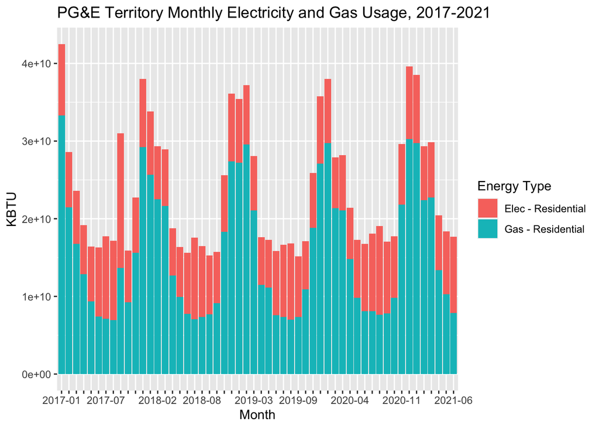

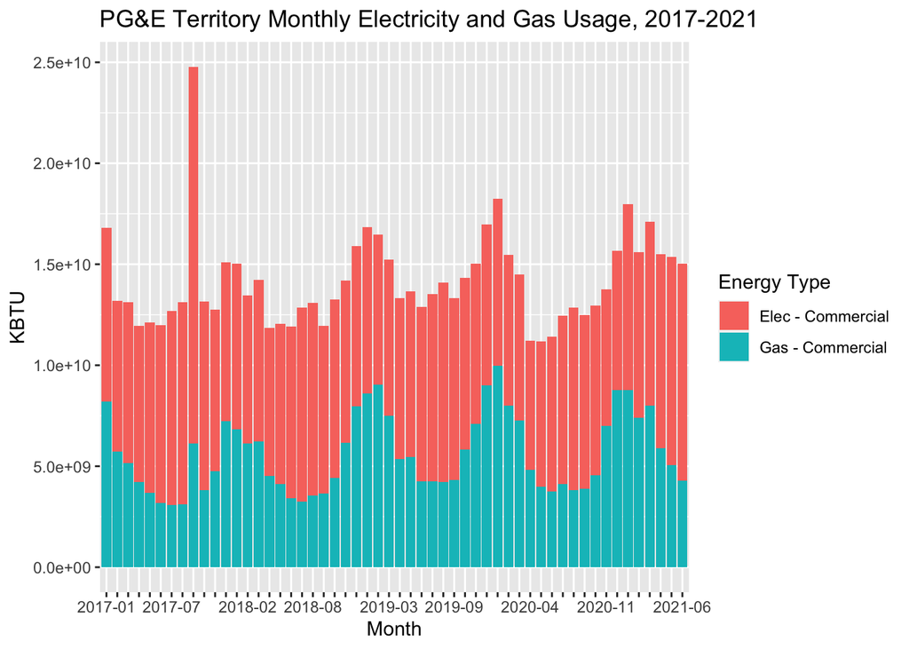